# t-SNE for Sugimoto-san

ryamada

2018年10月21日

```r
knit_hooks$set(webgl = hook_webgl)
```

# t-SNE とは

[この記事](https://blog.albert2005.co.jp/2015/12/02/tsne/) を参考にできるでしょう。

または、記事からもリンクが張ってある[原論文](https://lvdmaaten.github.io/publications/papers/JMLR_2008.pdf)にあたるのもよいです。

# Rを使ってt-SNEの処理についてなぞってみる

計算機言語で処理をなぞることは、異なる言語で理解することなので、本当に解っていないとできません。

逆に言うと、異なる言語(今の場合はR)で理解しようとすることで、紛れのない理解を目指せるということです。

# t-SNEという名称

t-分布を使った of Stochastic Neighbor Embedding 。

Stochastic : 確率の→確率分布を用いた

Neighbor : 近い→近いものを近くに、遠いものを遠くに

Embedding : 埋め込み→高次元空間の点を低次元空間に埋め込む

# 高次元空間の2点間の『距離』

## ユークリッド距離

```r
# 次元
d <- 3
v1 <- rnorm(d)
v2 <- rnorm(d)
v1
```

```
## [1] -1.1923313  0.8908062  1.6529144
```

```r
v2
```

```
## [1]  0.6334458  2.1347648 -1.0060672
```

```r
library(rgl)
plot3d(rbind(v1,v2))
spheres3d(rbind(v1,v2),radius=0.005)
segments3d(rbind(v1,v2),color=2)
```

2点間の距離をユークリッド距離で測ると

$$d_{eu}(v1,v2) = \sqrt{(v1_x-v2_x)^2+(v1_y-v2_y)^2+(v1_z-v2_z)^2}$$

```r
d.eu <- sqrt(sum((v1-v2)^2))
```

## 確率分布的な遠近の程度を値にする(距離のようなもの)

t-SNEの方法は2つのことを考慮します。

- ある点の周りに、多次元正規分布を仮定すること
- たくさんの観測点に重みをつけること

今、全部でN個の点が観察されたとします。

$Vi$から$Vj$への遠近の程度の値$\delta_{i \to j}$を考えます。

$Vi$の周りには、$N-1$個の点が観察されているので、$N-1$個の点に、$Vi$からの遠近の値$\delta_{i \to j}$を定めることとし、

その値は、

$$\sum_{j \ne i} \delta_{i \to j} = 1$$

となるようにします。

ここで、$\delta_{i \to j}$は、$Vi$と$Vj$とのユークリッド距離が短ければ大きく、 ユークリッド距離が長ければ小さくなるように取ることにします。

$Vi$の周囲に多次元正規分布があると見ると、$Vi$からの距離が短いときに 高確率、遠いときに低確率で点が発生するので、正規分布の確率密度関数を使って、$\delta_{i \to j}$を定めることにします。

遠近関係を一番すなおな確率分布で定めることになります。

正規分布の確率密度関数は

$$Pr(V_j | V_i) = \frac{1}{\sqrt{2\pi \sigma^2}}e^{-\frac{||V1-V2|| ^2}{2\sigma^2}}$$

で表されるので、

$$\delta_{i \to j} = \frac{Pr(V_j | V_i)}{\sum_{k \ne i}Pr(V_k|V_i)}$$

となります。

ちなみに$Vi$から$Vi$の値は考慮に入れないという意味で0とします。

このように計算すると、$\delta_{i \to j}$と$\delta_{j \to i}$の値は異なりますが、それは低次元空間に埋め込んで、低次元空間での「遠近」関係で考えるときに困るので、$\delta_{i \to j}$と$\delta_{j \to i}$との平均値を取ることにします。 、

$$\frac{\delta_{i \to j}+\delta_{j \to i}}{2}$$
さらに、ちょっと工夫と加えて
$$\Delta(i<->j) = \frac{1}{N}\frac{\delta_{i \to j}+\delta_{j \to i}}{2}$$
とします。これにより、すべての点がこの遠近量にいくばくかの寄与はするように補正がかかるそうです。

# Rでやってみる

## まず、関数を作る。

```r
normIJ <- function(vi,vj,s=1){
  1/sqrt(2*pi*s^2)* exp(-sqrt(sum((vi-vj)^2))/(2*s^2))
}
deltaMatrix <- function(Vs,s){
  N <- length(Vs[,1])
  m <- matrix(0,N,N)
  for(i in 1:N){
    for(j in 1:N){
      if(i == j){

      }else{
        m[i,j] <- normIJ(Vs[i,],Vs[j],s=s)
      }
    }
  }
  return(m)
}
deltaIJ <- function(dMat){
  rsum <- rowSums(dMat) # 行和
  ret <- dMat/rsum
  return(ret)
}
DeltaIJ <- function(deltaIJ){
  N <- length(deltaIJ[,1])
  ret <- (deltaIJ + t(deltaIJ))/(2*N)
  return(ret)
}
# 上の関数をまとめる
my.DeltaIJ <- function(Vs,s){
  dMat <- deltaMatrix(Vs,s)
  ret1 <- deltaIJ(dMat)
  ret2 <- DeltaIJ(ret1)
  return(ret2)
}
```

## データを作る

```r
# 次元
d <- 3
# クラスタの数
n.cluster <- 3
# クラスタごとの点の数
Ns <- sample(100:500,n.cluster,replace=TRUE)
# クラスタごとの点の座標
Xs <- list()
for(i in 1:n.cluster){
  Xs[[i]] <- matrix(rnorm(Ns[i]*d),ncol=d)
  # 軸ごとに平行移動して、分散を変える
  for(j in 1:d){
    Xs[[i]][,j] <- (Xs[[i]][,j] + rnorm(1)) * rnorm(1)
  }
}
# 全点をまとめる
Xall <- matrix(0,0,3)
for(i in 1:n.cluster){
  Xall <- rbind(Xall,Xs[[i]])
}

plot3d(Xall)
```

## t-SNEの遠近行列を計算してみる

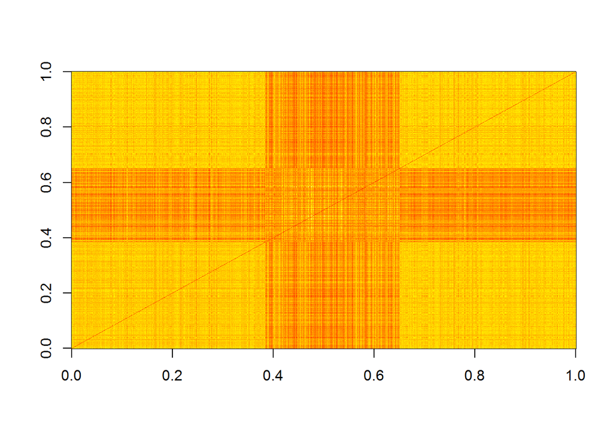

```r
Deltamat <- my.DeltaIJ(Xall,s=1)
image(Deltamat)
```

ユークリッド距離と比べてみる

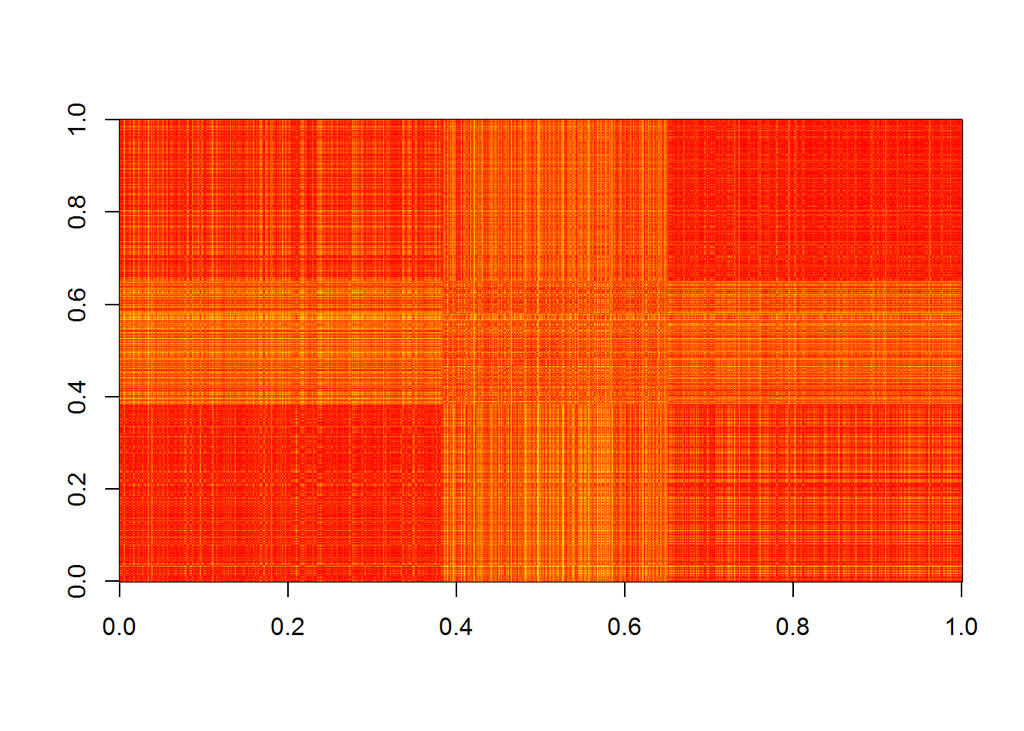

```r
Deu <- as.matrix(dist(Xall))
image(Deu)
```

遠近のコントラストがユークリッド距離よりもついている様子が見える